# Chapter 7. How Sure Can We Be About What Is going On? Estimates and Intervals

## 불확실성을 인지하는 것이 중요하다

- 통계조사 결과 평균이 3000명 감소
  - 에러가 $\pm 77,000$이라면? 3,000명이 감소했다고 말할 수 있는가?
- 잘 실행된 조사인 경우, 우리는 샘플평균이 population mean에 가깝다고 추정한다
  - 참고사항: 샘플 파라미터는 로마자(m)로 population 파라미터는 그리스 문자($\mu$)로 쓰는 경우가 많다

## Bootstrapping

- 샘플(조사결과)가 하나 있을 때 어떻게 불확실성을 알 수 있을까?
  - 방법 1) 통계 모형을 설정해서 구한다.
    - 많은 가설을 도입해야 한다. 모집단의 분포가 어떨지 결정해야 한다.
  - 방법 2) 샘플을 다시 샘플링 한다면?
    - 적은 가설을 가지고 할 수 있다.
- Bootstrapping: resampling from sample
  - 가정: 샘플분포가 모집단 분포와 비슷하다.
  - 방법
    - 샘플을 다시 샘플링해서 resample의 평균의 분포를 본다.
    - 그렇다면 모집단에서 sampling했을 때의 불확실성과 비슷할 것이다.
  - 참고
    - 중심극한정리를 확인할 수 있다.
    - 만약에 모집단이 극단적인 값을 가질 수 있는 분포라면 bootstraping은 조심해야 한다.

## Bootstrapping sample

```python
import pandas as pd
import numpy as np
import matplotlib.pyplot as plt
import seaborn as sns

plt.style.use('seaborn')
sns.set(font_scale=2.5)
```

모분포를 임의로 만들었습니다. (3개의 가우시안 분포를 기반으로 합성해서 만든 샘플입니다.)

```
(0.0, 60.0)
```

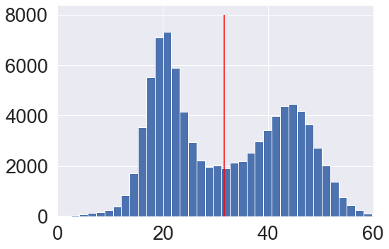

```python
# generate population

population = np.concatenate(
    [
        np.random.normal(20, 3, size=30000),
        np.random.normal(30, 10, size=30000),
        np.random.normal(45, 5, size=30000),
    ]
)
plt.hist(population, bins=50)
plt.vlines(population.mean(), 0, 8000, color="red")
plt.xlim(0, 60)
```

모분포에서 size를 10, 100, 1000, 10000으로 늘려가며 샘플링을 하면 점점 모분포와 유사해지는 것을 알 수 있습니다.

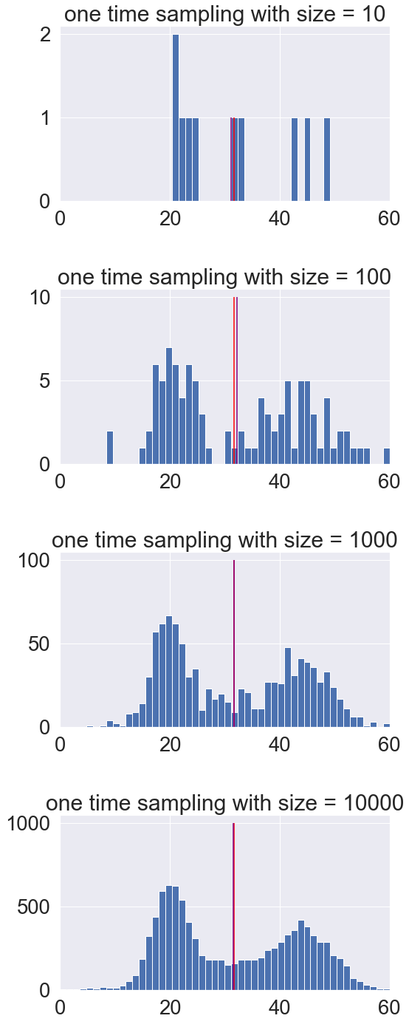

```python
samples = [ np.random.choice(population, size=i)  for i in [10, 100, 1000, 10000]]

fig, ax = plt.subplots(len(samples), 1, figsize=(8,24))
for i, sample in enumerate(samples):
    ax[i].hist(sample, bins=50, range=(0, 60))
    ax[i].set_xlim(0, 60)
    ax[i].set_title(f"one time sampling with size = {len(sample)}")
    ax[i].vlines(population.mean(), 0, len(sample)/10, color="red")
    ax[i].vlines(sample.mean(), 0, len(sample)/10, color="purple")
plt.subplots_adjust(wspace=0.2, hspace=0.5)
plt.show()
```

Bootstrapping을 하면, 샘플사이즈가 커지면 커질수록 평균의 분포가 집중되는 것을 볼 수 있으며, 일정 수준이 넘어간 경우 반복횟수는 큰 영향이 없는 것을 확인할 수 있습니다.

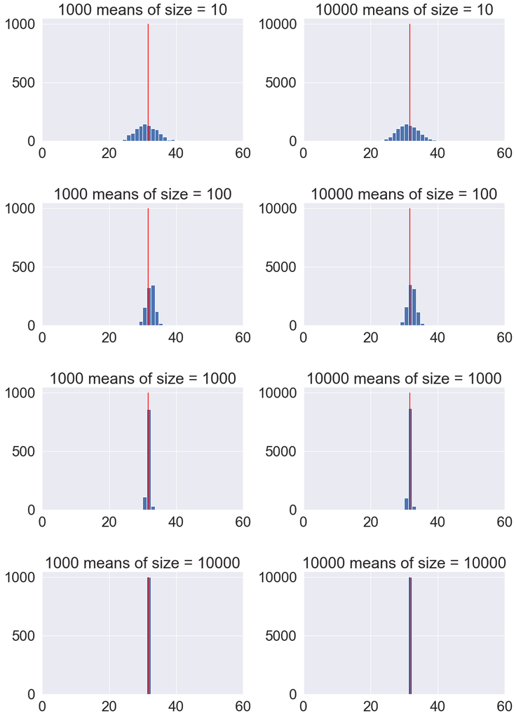

```python
# conduct bootstrapping with sample size n

def bootstrap(population, size, n):
    output = []
    for i in range(n):
        output.append(np.random.choice(population, size=size).mean())
    return output

fig, ax = plt.subplots(4, 2, figsize=(16, 24))
# 1000 resamples
for i, size in enumerate([10, 100, 1000, 10000]):
    output = bootstrap(samples[i], size, 1000)
    ax[i][0].hist(output, bins=50, range=(0, 60))
    ax[i][0].set_xlim(0, 60)
    ax[i][0].set_title(f"1000 means of size = {size}")
    ax[i][0].vlines(population.mean(), 0, 1000, color="red")
# 100000 resamples
for i, size in enumerate([10, 100, 1000, 10000]):
    output = bootstrap(samples[i], size, 10000)
    ax[i][1].hist(output, bins=50, range=(0, 60))
    ax[i][1].set_xlim(0, 60)
    ax[i][1].set_title(f"10000 means of size = {size}")
    ax[i][1].vlines(population.mean(), 0, 10000, color="red")

plt.subplots_adjust(wspace=0.3, hspace=0.5)
plt.show()
```